# Microglia_monocyte_comparisons_ranking

Gijsje

2/24/2021

# Load microglia specific genes and monocytes/macrophages dataset based on Patir et al and Haage et al. 2019

```r
Patir = "~/Documents/MiGASti/Databases/Patir_2sets.xlsx"
Patir = read_excel(Patir, col_names = TRUE)
Patir = as.data.frame(Patir)
```

# Load MiGASTi unstim

#metadata + genes_counts

```r
metadata <- read.table("~/Documents/MiGASti/Databases/metadata.txt")
#set rownames to Sample
row.names(metadata) <- metadata$Sample
setwd("~/Documents/MiGASti/Databases")
#exclude samples that did not pass QC filtering
exclude <- read.table("samples2remove.txt")
exclude <- exclude$x
#Excludes the samples from filters.
#dim(genes_counts_filt)
metadata_filt = metadata[ !(rownames(metadata) %in% exclude), ]
length(metadata_filt)

#load gene matrix
load("~/Documents/MiGASti/Databases/gene_matrix.RData")
genes_counts_filt = genes_counts[, !colnames(genes_counts) %in% exclude]
#Excludes the samples from filters.

metadata <- subset(metadata_filt, Stimulation == "unstim")
genes_counts_filt2 <- genes_counts_filt[, colnames(genes_counts_filt) %in% metadata$Sample]
head(rownames(genes_counts_filt2))
genes_counts_migasti <- genes_counts_filt2
metadata_migasti <- metadata
#check ordering
genes_counts_migasti <- genes_counts_migasti[,rownames(metadata_migasti)]
all(rownames(metadata_migasti) == colnames (genes_counts_migasti)) #TRUE
gencode_30 = read.table("~/Documents/MiGASti/Databases/ens.geneid.gencode.v30")
colnames(gencode_30) = c("ensembl","symbol")
setDT(genes_counts_migasti, keep.rownames = "ensembl")
genes_counts_migasti$ensembl
res_name = merge(genes_counts_migasti, gencode_30, by="ensembl")
rownames(res_name) = res_name$ensembl
```

### Top 50 genes migasti unstim

```r
res_name2 <- res_name
genes_v <- res_name$ensembl
genes <- as.data.frame(genes_v)
res_name2$ensembl <- NULL
res_name2$symbol <- NULL
sum <- rowMeans(res_name2)
top <- cbind(sum, genes)
expr3 <- top[order(top$sum, decreasing=TRUE),]
colnames(expr3)[2] <- "ensembl"
merged_migasti_unstim <- merge(gencode_30, expr3, by = "ensembl")
merged_migasti_unstim <- merged_migasti_unstim[order(merged_migasti_unstim$sum, decreasing =T),]
merged_migasti_unstim[1:50, ]
```

|  | ensembl | symbol | sum |
| --- | --- | --- | --- |
| 12253 | ENSG00000167996.16 | FTH1 | 310855.10 |
| 21444 | ENSG00000210082.2 | MT-RNR2 | 307432.34 |
| 1720 | ENSG00000087086.15 | FTL | 294689.70 |
| 4846 | ENSG00000118785.14 | SPP1 | 205768.63 |
| 12598 | ENSG00000169429.11 | CXCL8 | 204778.08 |
| 54591 | ENSG00000277632.2 | CCL3 | 154423.84 |
| 39869 | ENSG00000251562.8 | MALAT1 | 97257.89 |
| 5674 | ENSG00000125538.11 | IL1B | 87933.12 |
| 4001 | ENSG00000112096.18 | SOD2 | 83692.04 |
| 1317 | ENSG00000075624.15 | ACTB | 65065.54 |

[output cut: 40 more lines]

```r
migasti_unstim <- merged_migasti_unstim[1:50, ]
```

### Selected genes based on Patir and Haage et al.

```r
marker_expression_MiGAsti <- merge(res_name, Patir, by = "symbol")
marker_expression_migasti <- marker_expression_MiGAsti[!duplicated(marker_expression_MiGAsti$symbol), ]
genes_v <- marker_expression_migasti$symbol
marker_expression_migasti$symbol <-NULL
marker_expression_migasti$ensembl <- NULL
marker_expression_cor <- rowMeans(marker_expression_migasti)
expr <- as.data.frame(marker_expression_cor)
expr2 <- cbind(expr, genes_v)

expr3 <- expr2[order(expr2$marker_expression_cor, decreasing = T),]
expr3$rank <- 1:nrow(expr3)
data.table(expr3)
```

| marker_expression_cor | genes_v | rank |
| --- | --- | --- |
| 2.057686e+05 | SPP1 | 1 |
| 5.042319e+04 | B2M | 2 |
| 3.747405e+04 | CTSB | 3 |
| 3.585923e+04 | SAT1 | 4 |
| 1.896984e+04 | IFI30 | 5 |
| 1.731569e+04 | ANXA2 | 6 |
| 1.460722e+04 | LAPTM5 | 7 |
| 1.388770e+04 | FCER1G | 8 |
| 1.233230e+04 | CD74 | 9 |
| 1.135087e+04 | S100A11 | 10 |

[output cut: 391 more lines]

# Load MiGASTi ununstim

```r
metadata <- read.table("~/Documents/MiGASti/Databases/metadata.txt")
#set rownames to Sample
row.names(metadata) <- metadata$Sample
setwd("~/Documents/MiGASti/Databases")
#exclude samples that did not pass QC filtering
exclude <- read.table("samples2remove.txt")
exclude <- exclude$x
#Excludes the samples from filters.
#dim(genes_counts_filt)
metadata_filt = metadata[ !(rownames(metadata) %in% exclude), ]
length(metadata_filt)

#load gene matrix
load("~/Documents/MiGASti/Databases/gene_matrix.RData")
genes_counts_filt = genes_counts[, !colnames(genes_counts) %in% exclude]
#Excludes the samples from filters.

metadata <- subset(metadata_filt, Stimulation == "ununstim")
genes_counts_filt2 <- genes_counts_filt[, colnames(genes_counts_filt) %in% metadata$Sample]
head(rownames(genes_counts_filt2))
genes_counts_migasti <- genes_counts_filt2
metadata_migasti <- metadata
#check ordering
genes_counts_migasti <- genes_counts_migasti[,rownames(metadata_migasti)]
all(rownames(metadata_migasti) == colnames (genes_counts_migasti)) #TRUE
gencode_30 = read.table("~/Documents/MiGASti/Databases/ens.geneid.gencode.v30")
colnames(gencode_30) = c("ensembl","symbol")
setDT(genes_counts_migasti, keep.rownames = "ensembl")
genes_counts_migasti$ensembl
res_name = merge(genes_counts_migasti, gencode_30, by="ensembl")
rownames(res_name) = res_name$ensembl
expr_migasti_unstim <- expr3
```

### Top 50 genes migasti ununstim

```r
res_name2 <- res_name
genes_v <- res_name2$ensembl
genes <- as.data.frame(genes_v)
res_name2$ensembl <- NULL
res_name2$symbol <- NULL
sum <- rowMeans(res_name2)
top <- cbind(sum, genes)
expr3 <- top[order(top$sum, decreasing = TRUE),]
colnames(expr3)[2] <- "ensembl"
merged_migasti_ununstim <- merge(gencode_30, expr3, by = "ensembl")
merged_migasti_ununstim <- merged_migasti_unstim[order(merged_migasti_unstim$sum, decreasing =T),]
merged_migasti_ununstim[1:50, ]
```

|  | ensembl | symbol | sum |
| --- | --- | --- | --- |
| 12253 | ENSG00000167996.16 | FTH1 | 310855.10 |
| 21444 | ENSG00000210082.2 | MT-RNR2 | 307432.34 |
| 1720 | ENSG00000087086.15 | FTL | 294689.70 |
| 4846 | ENSG00000118785.14 | SPP1 | 205768.63 |
| 12598 | ENSG00000169429.11 | CXCL8 | 204778.08 |
| 54591 | ENSG00000277632.2 | CCL3 | 154423.84 |
| 39869 | ENSG00000251562.8 | MALAT1 | 97257.89 |
| 5674 | ENSG00000125538.11 | IL1B | 87933.12 |
| 4001 | ENSG00000112096.18 | SOD2 | 83692.04 |
| 1317 | ENSG00000075624.15 | ACTB | 65065.54 |

[output cut: 40 more lines]

```r
migasti_ununstim <- merged_migasti_ununstim[1:50, ]
```

### Selected genes based on Patir and Haage et al.

```r
marker_expression_MiGAsti = merge(res_name, Patir, by ="symbol")

marker_expression_migasti <- marker_expression_MiGAsti[!duplicated(marker_expression_MiGAsti$symbol), ]
genes_v <- marker_expression_migasti$symbol
marker_expression_migasti$symbol <-NULL
marker_expression_migasti$ensembl <- NULL
marker_expression_cor <- rowMeans(marker_expression_migasti)
expr <- as.data.frame(marker_expression_cor)
expr2 <- cbind(expr, genes_v)

expr3 <- expr2[order(expr2$marker_expression_cor, decreasing = TRUE),]
expr3$rank <- 1:nrow(expr3)
data.table(expr3)
```

| marker_expression_cor | genes_v | rank |
| --- | --- | --- |
| 6.257648e+05 | SPP1 | 1 |
| 3.296415e+05 | CD74 | 2 |
| 2.267756e+05 | B2M | 3 |
| 1.704146e+05 | CTSB | 4 |
| 1.387966e+05 | SAT1 | 5 |
| 8.339850e+04 | RGS1 | 6 |
| 8.142702e+04 | HLA-DRA | 7 |
| 5.007005e+04 | LAPTM5 | 8 |
| 4.804957e+04 | C1QB | 9 |
| 3.838798e+04 | IFI30 | 10 |

[output cut: 391 more lines]

```r
expr_migasti_ununstim <- expr3
```

# Load MiGA dataset

#genes_counts + metadata

```r
load("~/Documents/MiGA/gene_matrix.RData")
load("~/Documents/MiGA/metadata_255filt_eng_29jun2020.Rdata")
genes_counts_miga <- genes_counts
metadata_miga <- metadata3rd_pass
genes_counts_miga <- genes_counts_miga[, colnames(genes_counts_miga) %in% metadata_miga$donor_tissue]
rownames(metadata_miga) <- metadata_miga$donor_tissue
genes_counts_miga <- genes_counts_miga[,rownames(metadata_miga)]
all(rownames(metadata_miga) == colnames (genes_counts_miga)) #TRUE

gencode_30 = read.table("~/Documents/MiGASti/Databases/ens.geneid.gencode.v30")
colnames(gencode_30) = c("ensembl","symbol")
setDT(genes_counts_miga, keep.rownames = "ensembl")
genes_counts_miga$ensembl
res_name = merge(genes_counts_miga, gencode_30, by="ensembl")
rownames(res_name) = res_name$ensembl
```

```r
res_name2 <- res_name
genes_v <- res_name$ensembl
genes <- as.data.frame(genes_v)
res_name2$ensembl <- NULL
res_name2$symbol <- NULL
sum <- rowMeans(res_name2)
top <- cbind(sum, genes)
expr3 <- top[order(top$sum, decreasing=TRUE),]
colnames(expr3)[2] <- "ensembl"
merged_miga <- merge(gencode_30, expr3, by = "ensembl")
merged_miga <- merged_miga[order(merged_miga$sum, decreasing =T),]
merged_miga[1:50, ]
```

|  | ensembl | symbol | sum |
| --- | --- | --- | --- |
| 21444 | ENSG00000210082.2 | MT-RNR2 | 873043.61 |
| 4846 | ENSG00000118785.14 | SPP1 | 241063.44 |
| 17884 | ENSG00000198804.2 | MT-CO1 | 205493.40 |
| 39869 | ENSG00000251562.8 | MALAT1 | 170781.02 |
| 395 | ENSG00000019582.15 | CD74 | 164442.28 |
| 1317 | ENSG00000075624.15 | ACTB | 148313.14 |
| 11917 | ENSG00000166710.19 | B2M | 148184.98 |
| 1720 | ENSG00000087086.15 | FTL | 143166.44 |
| 20225 | ENSG00000205542.11 | TMSB4X | 127200.51 |
| 19860 | ENSG00000204389.9 | HSPA1A | 125239.27 |

[output cut: 40 more lines]

```r
miga <- merged_miga[1:50, ]
```

### Selected genes based on Patir and Haage et al.

```r
marker_expression_MiGA = merge(res_name, Patir, by ="symbol")

marker_expression_miga <- marker_expression_MiGA[!duplicated(marker_expression_MiGA$symbol), ]
genes_v <- marker_expression_miga$symbol
marker_expression_miga$ensembl <- NULL
marker_expression_miga$symbol <- NULL
marker_expression_cor <- rowMeans(marker_expression_miga)
expr <- as.data.frame(marker_expression_cor)
expr2 <- cbind(expr, genes_v)
expr3 <- expr2[order(expr2$marker_expression_cor, decreasing = TRUE),]
expr3$rank <- 1:nrow(expr3)
data.table(expr3)
```

| marker_expression_cor | genes_v | rank |
| --- | --- | --- |
| 2.410634e+05 | SPP1 | 1 |
| 1.644423e+05 | CD74 | 2 |
| 1.481850e+05 | B2M | 3 |
| 7.970888e+04 | HLA-DRA | 4 |
| 6.900024e+04 | CTSB | 5 |
| 6.504196e+04 | C3 | 6 |
| 5.520290e+04 | RGS1 | 7 |
| 4.038757e+04 | C1QB | 8 |
| 3.836702e+04 | SAT1 | 9 |
| 3.739057e+04 | CSF1R | 10 |

[output cut: 391 more lines]

```r
expr_miga <- expr3
```

# Load cultured monocyte dataset

#genes_counts + metadata #only monocytes baseline cultured

```r
load("~/Documents/Monocytes/gene_matrix.RData")
genes_counts_monocytes <- genes_counts
metadata_monocytes <- read.csv("~/Documents/Monocytes/merged_meta_lrrk2_105.csv", header=TRUE)

metadata_monocytes <- subset(metadata_monocytes, treatment == "Basal")
genes_counts_monocytes <- genes_counts_monocytes[, colnames(genes_counts_monocytes) %in% metadata_monocytes$sample_id]
rownames(metadata_monocytes) = metadata_monocytes$sample_id
# check ordering of data
genes_counts_monocytes <- genes_counts_monocytes[,rownames(metadata_monocytes)]
all(rownames(metadata_monocytes) == colnames (genes_counts_monocytes)) #TRUE

gencode_30 = read.table("~/Documents/MiGASti/Databases/ens.geneid.gencode.v30")
colnames(gencode_30) = c("ensembl","symbol")
setDT(genes_counts_monocytes, keep.rownames = "ensembl")
genes_counts_monocytes$ensembl
res_name = merge(genes_counts_monocytes, gencode_30, by="ensembl")
rownames(res_name) = res_name$ensembl
marker_expression_monocytes = merge(res_name, Patir, by ="symbol")
```

### Top 50 genes monocytes

```r
res_name2 <- res_name
genes_v <- res_name$ensembl
genes <- as.data.frame(genes_v)
res_name2$ensembl <- NULL
res_name2$symbol <- NULL
sum <- rowMeans(res_name2)
top <- cbind(sum, genes)
expr3 <- top[order(top$sum, decreasing=TRUE),]
colnames(expr3)[2] <- "ensembl"
merged_monocytes <- merge(gencode_30, expr3, by = "ensembl")
merged_monocytes <- merged_monocytes[order(merged_monocytes$sum, decreasing =T),]
merged_monocytes[1:50, ]
```

|  | ensembl | symbol | sum |
| --- | --- | --- | --- |
| 1876 | ENSG00000090382.6 | LYZ | 310174.42 |
| 21444 | ENSG00000210082.2 | MT-RNR2 | 167394.29 |
| 4047 | ENSG00000112308.13 | C6orf62 | 155535.04 |
| 1720 | ENSG00000087086.15 | FTL | 144003.26 |
| 12253 | ENSG00000167996.16 | FTH1 | 101259.60 |
| 1317 | ENSG00000075624.15 | ACTB | 97536.49 |
| 11795 | ENSG00000166224.16 | SGPL1 | 77566.24 |
| 8381 | ENSG00000143376.14 | SNX27 | 76786.86 |
| 17522 | ENSG00000197746.14 | PSAP | 76658.46 |
| 11425 | ENSG00000164733.21 | CTSB | 67072.51 |

[output cut: 40 more lines]

```r
cultured_monocytes <- merged_monocytes[1:50, ]
```

### Selected genes based on Patir and Haage et al.

```r
marker_expression_monocytes <- marker_expression_monocytes[!duplicated(marker_expression_monocytes$symbol), ]
genes_v <- marker_expression_monocytes$symbol
marker_expression_monocytes$ensembl <- NULL
marker_expression_monocytes$symbol <- NULL
marker_expression_cor <- rowMeans(marker_expression_monocytes)
expr <- as.data.frame(marker_expression_cor)
expr2 <- cbind(expr, genes_v)

expr3 <- expr2[order(expr2$marker_expression_cor, decreasing = TRUE),]
expr3$rank <- 1:nrow(expr3)
data.table(expr3)
```

| marker_expression_cor | genes_v | rank |
| --- | --- | --- |
| 3.101744e+05 | LYZ | 1 |
| 6.707251e+04 | CTSB | 2 |
| 6.579300e+04 | IFI30 | 3 |
| 5.778291e+04 | B2M | 4 |
| 4.009365e+04 | ITGAX | 5 |
| 3.552406e+04 | CTSS | 6 |
| 3.460997e+04 | CYBB | 7 |
| 3.053029e+04 | HLA-DRA | 8 |
| 2.724443e+04 | FN1 | 9 |
| 2.368660e+04 | CD74 | 10 |

[output cut: 391 more lines]

# Load macrophage dataset

### Top 50 genes macrophages

```r
load("~/Documents/MiGASti/Databases/macrophage_data.Rdata")
genes_v <- macrophage_data$symbol
genes <- as.data.frame(genes_v)
macrophage_data$ensembl <- NULL
macrophage_data$symbol <- NULL
macrophage_data$V2 <- as.numeric(macrophage_data$V2)
macrophage_data$V2.1 <- as.numeric(macrophage_data$V2.1)
macrophage_data$V2.2 <- as.numeric(macrophage_data$V2.2)
macrophage_data$V2.3 <- as.numeric(macrophage_data$V2.3)
macrophage_data$V2.4 <- as.numeric(macrophage_data$V2.4)
macrophage_data$V2.5 <- as.numeric(macrophage_data$V2.5)
macrophage_data$V2.6 <- as.numeric(macrophage_data$V2.6)
macrophage_data$V2.7 <- as.numeric(macrophage_data$V2.7)

sum <- rowMeans(macrophage_data)
sum2 <- as.data.frame(sum)
top <- cbind(sum, genes)
merged_macrophages <- top[order(top$sum, decreasing = TRUE),]
data.table(merged_macrophages[1:50, ])
macrophages <- merged_macrophages[1:50, ]
colnames(macrophages)[2] <- "symbol"
```

[output not shown]

### Selected genes based on Patir and Haage et al.

```r
load("~/Documents/MiGASti/Databases/macrophage_data.Rdata")
marker_expression_macrophages = merge(macrophage_data, Patir, by ="symbol")
marker_expression_macrophages <- marker_expression_macrophages[!duplicated(marker_expression_macrophages$symbol), ]
genes_v <- marker_expression_macrophages$symbol
marker_expression_macrophages$ensembl <- NULL
marker_expression_macrophages$symbol <- NULL
marker_expression_macrophages$V2 <- as.numeric(marker_expression_macrophages$V2)
marker_expression_macrophages$V2.1 <- as.numeric(marker_expression_macrophages$V2.1)
marker_expression_macrophages$V2.2 <- as.numeric(marker_expression_macrophages$V2.2)
marker_expression_macrophages$V2.3 <- as.numeric(marker_expression_macrophages$V2.3)
marker_expression_macrophages$V2.4 <- as.numeric(marker_expression_macrophages$V2.4)
marker_expression_macrophages$V2.5 <- as.numeric(marker_expression_macrophages$V2.5)
marker_expression_macrophages$V2.6 <- as.numeric(marker_expression_macrophages$V2.6)
marker_expression_macrophages$V2.7 <- as.numeric(marker_expression_macrophages$V2.7)
marker_expression_cor <- rowMeans(marker_expression_macrophages)
expr <- as.data.frame(marker_expression_cor)
expr2 <- cbind(expr, genes_v)

expr3 <- expr2[order(expr2$marker_expression_cor, decreasing = TRUE),]
expr3$rank <- 1:nrow(expr3)
data.table(expr3)
```

| marker_expression_cor | genes_v | rank |
| --- | --- | --- |
| 314512.125 | CD74 | 1 |
| 224260.750 | LYZ | 2 |
| 214241.625 | HLA-DRA | 3 |
| 114010.125 | B2M | 4 |
| 100922.750 | FN1 | 5 |
| 87076.125 | CTSB | 6 |
| 79771.375 | SERPINA1 | 7 |
| 73478.875 | GRN | 8 |
| 65267.625 | LCP1 | 9 |
| 63820.875 | HLA-B | 10 |

[output cut: 385 more lines]

```r
expr_macrophages <- expr3
```

# Load microglia ex vivo Gosselin

### Top 50 genes microglia ex vivo Gosselin

```r
EV = "~/Documents/MiGASti/Databases/Gosselin_ex_vivo.xlsx"
EV = read_excel(EV, sheet = "Read Counts", col_names = TRUE)
EV = as.data.frame(EV)
genes_v <- EV$symbol
genes <- as.data.frame(genes_v)
EV$symbol <- NULL

sum <- rowMeans(EV)
sum2 <- as.data.frame(sum)
top <- cbind(sum, genes)
merged_microglia_EV_Gosselin <- top[order(top$sum, decreasing = TRUE),]
data.table(merged_microglia_EV_Gosselin[1:50, ])
```

| sum | genes_v |
| --- | --- |
| 160483.62 | C3 |
| 104505.46 | SPP1 |
| 93363.71 | CD74 |
| 89898.29 | CSF1R |
| 88295.17 | A2M |
| 77654.88 | MALAT1 |
| 77492.88 | ACTB |
| 74845.42 | NEAT1 |
| 72854.71 | FOS |
| 63433.00 | PSAP |

[output cut: 40 more lines]

```r
microglia_EV_Gosselin <- merged_microglia_EV_Gosselin[1:50, ]
colnames(microglia_EV_Gosselin)[2] <- "symbol"
```

### Selected genes based on Patir and Haage et al.

```r
EV = "~/Documents/MiGASti/Databases/Gosselin_ex_vivo.xlsx"
EV = read_excel(EV, sheet = "Read Counts", col_names = TRUE)
EV = as.data.frame(EV)
marker_expression_microglia_EV_Gosselin = merge(EV, Patir, by ="symbol")
marker_expression_microglia_ev_Gosselin <- marker_expression_microglia_EV_Gosselin[!duplicated(marker_expression_microglia_EV_Gosselin$symbol), ]
genes_v <- marker_expression_microglia_ev_Gosselin$symbol

marker_expression_microglia_ev_Gosselin$symbol <- NULL

marker_expression_cor <- rowMeans(marker_expression_microglia_ev_Gosselin)
expr <- as.data.frame(marker_expression_cor)
expr2 <- cbind(expr, genes_v)

expr3 <- expr2[order(expr2$marker_expression_cor, decreasing = TRUE),]
expr3$rank <- 1:nrow(expr3)
data.table(expr3)
```

| marker_expression_cor | genes_v | rank |
| --- | --- | --- |
| 1.604836e+05 | C3 | 1 |
| 1.045055e+05 | SPP1 | 2 |
| 9.336371e+04 | CD74 | 3 |
| 8.989829e+04 | CSF1R | 4 |
| 5.993392e+04 | CTSB | 5 |
| 5.423883e+04 | SLCO2B1 | 6 |
| 3.932804e+04 | LAPTM5 | 7 |
| 3.919012e+04 | STAB1 | 8 |
| 3.900175e+04 | CX3CR1 | 9 |
| 3.188717e+04 | C1QB | 10 |

[output cut: 397 more lines]

# Load microglia in vitro Gosselin

### Top 50 genes microglia in vitro Gosselin

```r
IV = "~/Documents/MiGASti/Databases/Gosselin_invitro.xlsx"
IV = read_excel(IV, sheet = "Read Counts", col_names = TRUE)
IV = as.data.frame(IV)
genes_v <- IV$symbol
genes <- as.data.frame(genes_v)
IV$symbol <- NULL

sum <- rowMeans(IV)
sum2 <- as.data.frame(sum)
top <- cbind(sum, genes)
merged_microglia_IV_Gosselin <- top[order(top$sum, decreasing = TRUE),]
data.table(merged_microglia_IV_Gosselin[1:50, ])
```

| sum | genes_v |
| --- | --- |
| 1283288.45 | SPP1 |
| 514628.73 | CTSB |
| 443885.55 | FTL |
| 217781.59 | ACTB |
| 200437.41 | CTSD |
| 199944.68 | PSAP |
| 182553.23 | FTH1 |
| 112474.64 | CD14 |
| 93545.23 | SOD2 |
| 80939.64 | CXCL8 |

[output cut: 40 more lines]

```r
microglia_IV_Gosselin <- merged_microglia_IV_Gosselin[1:50, ]
colnames(microglia_IV_Gosselin)[2] <- "symbol"
```

### Selected genes based on Patir and Haage et al.

```r
IV = "~/Documents/MiGASti/Databases/Gosselin_invitro.xlsx"
IV = read_excel(IV, sheet = "Read Counts", col_names = TRUE)
IV = as.data.frame(IV)
marker_expression_microglia_IV_Gosselin = merge(IV, Patir, by ="symbol")
marker_expression_microglia_iv_Gosselin <- marker_expression_microglia_IV_Gosselin[!duplicated(marker_expression_microglia_IV_Gosselin$symbol), ]
genes_v <- marker_expression_microglia_iv_Gosselin$symbol

marker_expression_microglia_iv_Gosselin$symbol <- NULL

marker_expression_cor <- rowMeans(marker_expression_microglia_iv_Gosselin)
expr <- as.data.frame(marker_expression_cor)
expr2 <- cbind(expr, genes_v)

expr3 <- expr2[order(expr2$marker_expression_cor, decreasing = TRUE),]
expr3$rank <- 1:nrow(expr3)
data.table(expr3)
```

| marker_expression_cor | genes_v | rank |
| --- | --- | --- |
| 1.283288e+06 | SPP1 | 1 |
| 5.146287e+05 | CTSB | 2 |
| 1.124746e+05 | CD14 | 3 |
| 8.072164e+04 | LAPTM5 | 4 |
| 6.894277e+04 | B2M | 5 |
| 5.199045e+04 | STAB1 | 6 |
| 4.906809e+04 | CD163 | 7 |
| 4.759945e+04 | CD68 | 8 |
| 4.240350e+04 | LCP1 | 9 |
| 4.219277e+04 | IFI30 | 10 |

[output cut: 397 more lines]

# Load monocytes Gosselin

### Top 50 genes monocytes Gosselin

```r
mono = "~/Documents/MiGASti/Databases/Gosselin_monocytes.xlsx"
mono = read_excel(mono, sheet = "Read Counts", col_names = TRUE)
mono = as.data.frame(mono)
genes_v <- mono$symbol
genes <- as.data.frame(genes_v)
mono$symbol <- NULL

sum <- rowMeans(mono)
sum2 <- as.data.frame(sum)
top <- cbind(sum, genes)
merged_microglia_mono_Gosselin <- top[order(top$sum, decreasing = TRUE),]
data.table(merged_microglia_mono_Gosselin[1:50, ])
```

| sum | genes_v |
| --- | --- |
| 94994.3 | S100A9 |
| 92722.5 | ACTB |
| 87424.1 | LYZ |
| 61776.2 | PSAP |
| 44911.6 | HLA-B |
| 43301.1 | B2M |
| 42990.4 | VCAN |
| 41466.4 | CD74 |
| 38529.4 | FCN1 |
| 36344.4 | CTSS |

[output cut: 40 more lines]

```r
monocytes_Gosselin <- merged_microglia_mono_Gosselin[1:50, ]
colnames(monocytes_Gosselin)[2] <- "symbol"
```

### Selected genes based on Patir and Haage et al.

```r
mono = "~/Documents/MiGASti/Databases/Gosselin_invitro.xlsx"
mono = read_excel(mono, sheet = "Read Counts", col_names = TRUE)
mono = as.data.frame(mono)
marker_expression_microglia_mono_Gosselin = merge(mono, Patir, by ="symbol")
marker_expression_microglia_mono_Gosselin <- marker_expression_microglia_mono_Gosselin[!duplicated(marker_expression_microglia_mono_Gosselin$symbol), ]
genes_v <- marker_expression_microglia_mono_Gosselin$symbol

marker_expression_microglia_mono_Gosselin$symbol <- NULL

marker_expression_cor <- rowMeans(marker_expression_microglia_mono_Gosselin)
expr <- as.data.frame(marker_expression_cor)
expr2 <- cbind(expr, genes_v)

expr3 <- expr2[order(expr2$marker_expression_cor, decreasing = TRUE),]
expr3$rank <- 1:nrow(expr3)
data.table(expr3)
```

| marker_expression_cor | genes_v | rank |
| --- | --- | --- |
| 1.283288e+06 | SPP1 | 1 |
| 5.146287e+05 | CTSB | 2 |
| 1.124746e+05 | CD14 | 3 |
| 8.072164e+04 | LAPTM5 | 4 |
| 6.894277e+04 | B2M | 5 |
| 5.199045e+04 | STAB1 | 6 |
| 4.906809e+04 | CD163 | 7 |
| 4.759945e+04 | CD68 | 8 |
| 4.240350e+04 | LCP1 | 9 |
| 4.219277e+04 | IFI30 | 10 |

[output cut: 397 more lines]

# Percentage overlap top 50 genes between migasti unstimulated and other datasets

### + migasti ununstim

```r
overlap_migasti <- merge(migasti_unstim, migasti_ununstim, by = "symbol")
percentage_migasti = length(overlap_migasti$symbol)/length(migasti_unstim$symbol)*100
percentage_migasti
```

[1] 100

```r
list(overlap_migasti$symbol)
```

[[1]] [1] “ACTB” “ACTG1” “ANXA2” “ANXA5” “B2M” “CCL20”  
[7] “CCL3” “CCL3L1” “CCL4” “CCL4L2” “CD63” “CD83”  
[13] “CTSB” “CTSL” “CXCL8” “DDX5” “DNAJB1” “EEF1A1”  
[19] “FTH1” “FTL” “GAPDH” “H3F3B” “HLA-E” “HSP90AB1” [25] “HSPA1A” “HSPA1B” “HSPA6” “IFI30” “IL1B” “MALAT1”  
[31] “MT-ATP6” “MT-CO1” “MT-CO3” “MT-CYB” “MT-ND2” “MT-ND4”  
[37] “MT-RNR1” “MT-RNR2” “NFKBIA” “PLAUR” “PPP1R15A” “PSAP”  
[43] “SAT1” “SDCBP” “SOD2” “SPP1” “SQSTM1” “TMBIM6”  
[49] “TMSB4X” “UBC”

### + miga

```r
overlap_migasti_miga <- merge(migasti_unstim, miga, by = "symbol")
percentage_migasti_miga = length(overlap_migasti_miga$symbol)/length(migasti_unstim$symbol)*100
percentage_migasti_miga
```

[1] 54

```r
list(overlap_migasti_miga$symbol)
```

[[1]] [1] “ACTB” “B2M” “CTSB” “DDX5” “EEF1A1” “FTH1” “FTL”  
[8] “GAPDH” “H3F3B” “HLA-E” “HSPA1A” “HSPA1B” “HSPA6” “MALAT1” [15] “MT-ATP6” “MT-CO1” “MT-CO3” “MT-CYB” “MT-ND2” “MT-ND4” “MT-RNR1” [22] “MT-RNR2” “PSAP” “SAT1” “SPP1” “TMSB4X” “UBC”

### + cultured monocytes

```r
overlap_cultured_monocytes <- merge(migasti_unstim, cultured_monocytes, by = "symbol")
percentage_migasti_cultured_monocytes = length(overlap_cultured_monocytes$symbol)/length(migasti_unstim$symbol)*100
percentage_migasti_cultured_monocytes
```

[1] 24

```r
list(overlap_cultured_monocytes$symbol)
```

[[1]] [1] “ACTB” “B2M” “CTSB” “EEF1A1” “FTH1” “FTL” “IFI30”  
[8] “MALAT1” “MT-ND4” “MT-RNR2” “PSAP” “SDCBP”

### + macrophages

```r
overlap_macrophages <- merge(migasti_unstim, macrophages, by = "symbol")
percentage_migasti_macrophages = length(overlap_macrophages$symbol)/length(migasti_unstim$symbol)*100
percentage_migasti_macrophages
```

[1] 14

```r
list(overlap_macrophages$symbol)
```

[[1]] [1] “ACTB” “B2M” “CTSB” “FTH1” “FTL” “MALAT1” “PSAP”

### + ex vivo Gosselin

```r
overlap_microglia_EV_Gosselin <- merge(migasti_unstim, microglia_EV_Gosselin, by = "symbol")
percentage_migasti_EV_Gosselin = length(overlap_microglia_EV_Gosselin$symbol)/length(migasti_unstim$symbol)*100
percentage_migasti_EV_Gosselin
```

[1] 20

```r
list(overlap_microglia_EV_Gosselin$symbol)
```

[[1]] [1] “ACTB” “B2M” “CTSB” “DDX5” “FTL” “HLA-E” “HSPA1B” “MALAT1” [9] “PSAP” “SPP1”

### + in vitro Gosselin

```r
overlap_microglia_IV_Gosselin <- merge(migasti_unstim, microglia_IV_Gosselin, by = "symbol")
percentage_migasti_IV_Gosselin = length(overlap_microglia_IV_Gosselin$symbol)/length(migasti_unstim$symbol)*100
percentage_migasti_IV_Gosselin
```

[1] 32

```r
list(overlap_microglia_IV_Gosselin$symbol)
```

[[1]] [1] “ACTB” “ACTG1” “B2M” “CTSB” “CTSL” “CXCL8” “FTH1” “FTL”  
[9] “GAPDH” “IFI30” “IL1B” “MALAT1” “PSAP” “SAT1” “SOD2” “SPP1”

```r
overlap_microglia_mono_Gosselin <- merge(migasti_unstim, microglia_IV_Gosselin, by = "symbol")
percentage_migasti_mono_Gosselin = length(overlap_microglia_mono_Gosselin$symbol)/length(migasti_unstim$symbol)*100
percentage_migasti_mono_Gosselin
```

[1] 32

```r
list(overlap_microglia_mono_Gosselin$symbol)
```

[[1]] [1] “ACTB” “ACTG1” “B2M” “CTSB” “CTSL” “CXCL8” “FTH1” “FTL”  
[9] “GAPDH” “IFI30” “IL1B” “MALAT1” “PSAP” “SAT1” “SOD2” “SPP1”

# percentage between datasets

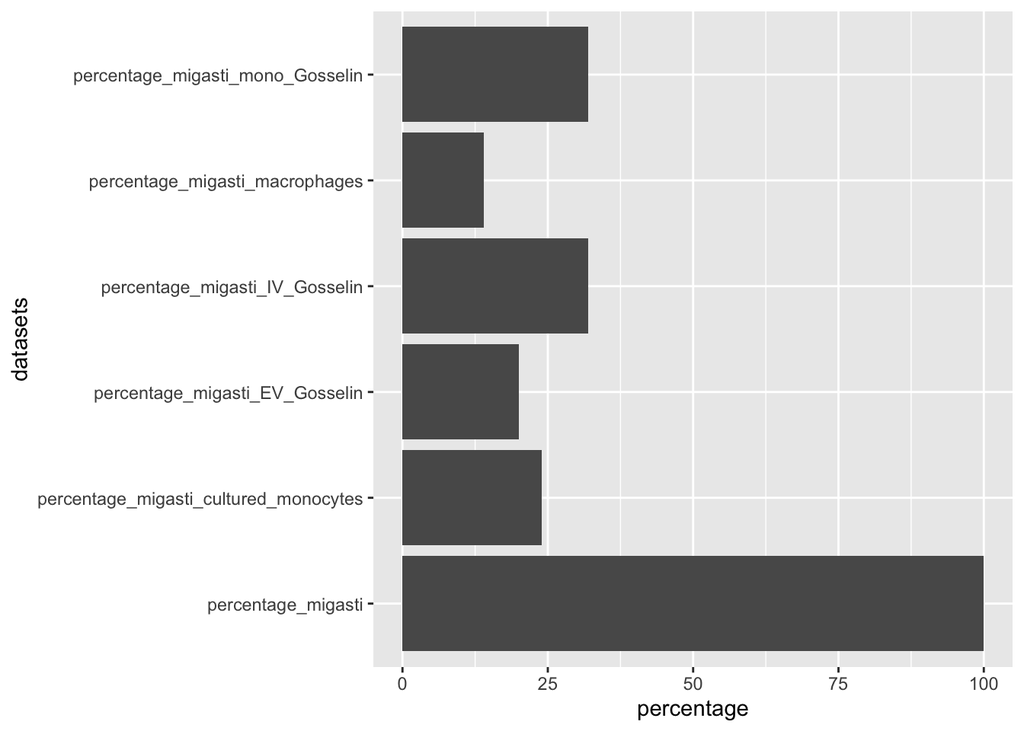

```r
percentage <- rbind(percentage_migasti, percentage_migasti_cultured_monocytes, percentage_migasti_macrophages, percentage_migasti_EV_Gosselin, percentage_migasti_IV_Gosselin,percentage_migasti_mono_Gosselin)

datasets <- rownames(percentage)

percentages <- cbind(datasets, percentage)

p<-ggplot(data=percentages, aes(x=percentage, y=datasets)) +
geom_bar(stat="identity")
p
```